# The Impact of Education on Entrepreneurship

December 4, 2014

## Research Question

- To what extent do teaching methods supporting self confidence affect the rate of entrepreneurship in OECD countries?

## Research Interest

**What determines entrepreneurship?**

- Economic and structural factors: Already searched
- Educational and cultural factors: Hardly searched
- Even when focused on attitudes / Entrepreneurship, studies look more at what attitudes are favourable, almost none searched what determines these attitudes.

## Causal Chain

1. Education System that reinforces self-confidence
2. Higher degree of individual self-esteem
3. Higher probability an individual becomes an entrepreneur
4. Higher rate of entrepreneurship at a country-level

## Where our Intuition Came From

| Variable | France | UK |
| --- | --- | --- |
| Fear of Failure (GEM 2012) | 43% | 36% |
| Perceived Capabilities (GEM 2012) | 36% | 47% |
| Sense of belonging (PISA 2012) | 47% | 79% |

## What is PISA

- PISA: "Programme for International Student Assessment is a triennial international survey which aims to evaluate education systems worldwide by testing the skills and knowledge of 15 year old students."
- Data availability prevented us from using PISA data for this project. For instance, for 2015 PISA will be looking at science education.

## What is GEM

- The Global Entrepreneurship Monitor project is an annual assessment of the entrepreneurial activity, aspirations, and attitudes of individuals across a wide range of countries.
- Only 10 countries at first, now covering 75% of world population and 89% of world GDP
- GEM is being used is regularly referred to in research, including in OECD reports.
- GEM uses primary data collection which results in massive comprehensive data sets. That is the 2001-2010 multi-year APS Database covers over 1.3 million observations over 85 countries.
- NES or National Expert Survey looks at 9 entrepreneurial framework conditions (4 national experts for each)

## Estimation Strategy

| Variable | Indicator |
| --- | --- |
| Y Dependent Variable | Rate of Entrepreneurship (Intention, Nascent, Established) |
| X1 Explanatory Variable | Way of Teaching |
| X2 Control Variable | Perceived Capabilities |
| X3 Control Variable | Fear of Failure / Perceived Opportunities |
| X4 Control Variable | Perceived Opportunities |

## How Much the Way of Teaching Supports Self-Confidence

- In the absence of an indicator directly aligned with our research design, we turned to an item of the GEM NES survey as a proxy, question D01:
- "In my country, teaching in primary and secondary education encourages creativity, self-sufficiency, and personal initiative"
- But there is a clear lack of consistency in the data.
- Many flaws : scale, methodology for collection (poor time management, personal connections)

## Variation in how the Way of Teaching is Perceived to Support Self-Confidence

## Variation in Perceived Impact of the Way of Teaching on Self Confidence

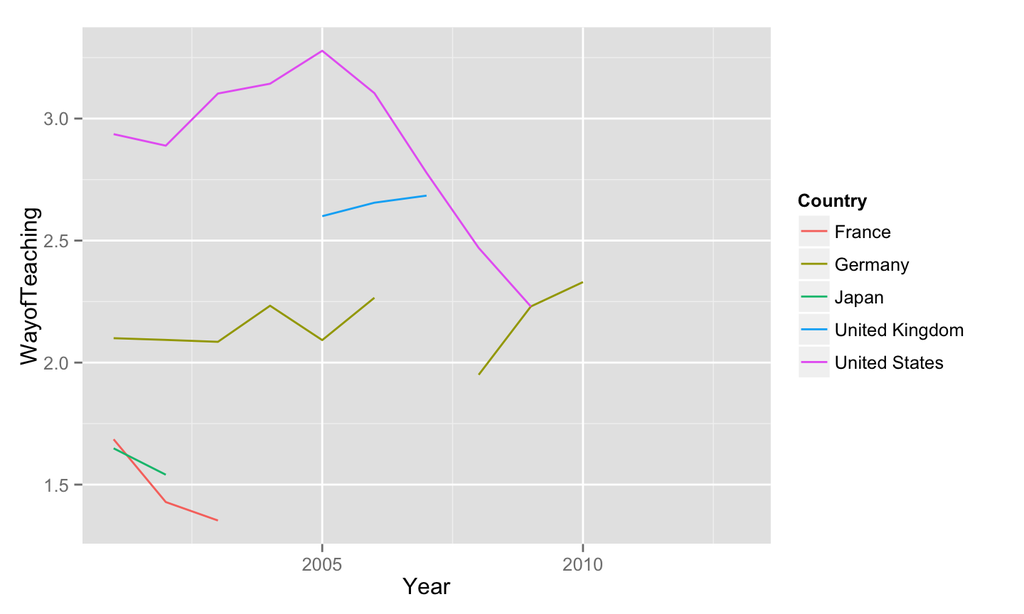

## Perceived Capabilities

- "Percentage of 18-64 population who believe they have the required skills and knowledge to start a business"
- This figure is a national-level percentage
- This measure was chosen to provide some insight on self-confidence at the country level

## Differences in Perceived Capabilities to start a Business

## Variation in Perceived Capabilities to Start a Business

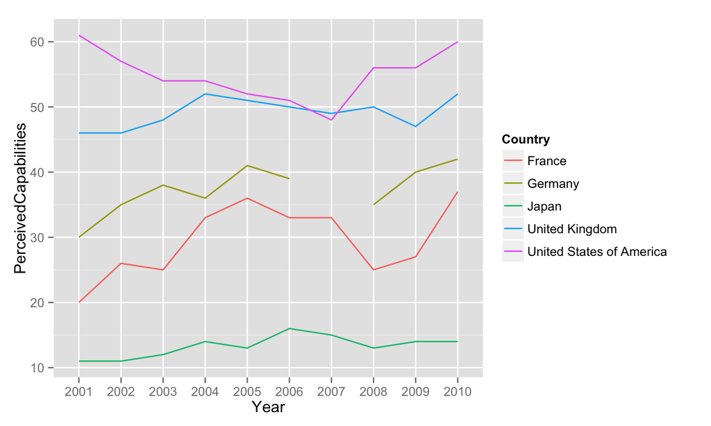

## Fear of Failure Despite Good Perceived Opportunities

- "Percentage of 18-64 population with positive perceived opportunities who indicate that fear of failure would prevent them from setting up a business."

## Variation in Fear of Failure Despite Perceived Good Opportunities

## Variation in Fear of Failure Despite Good Perceived Opportunities

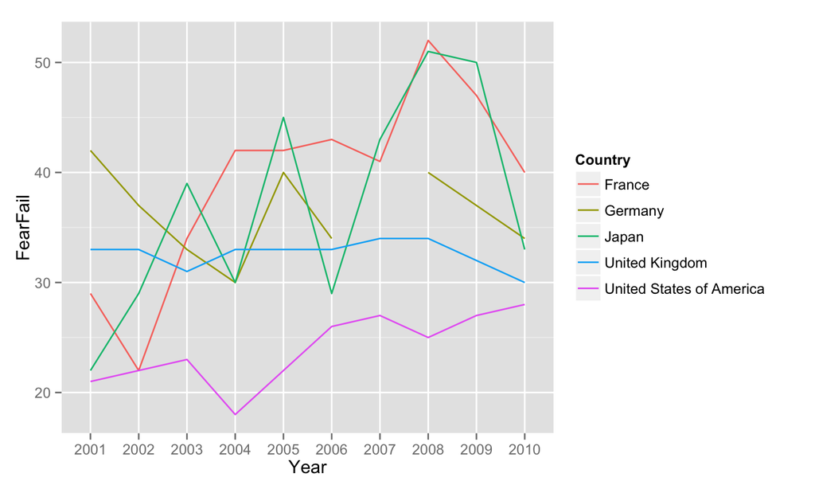

## Perceived Good Opportunities to Start a Business

- "Percentage of 18-64 population who see good opportunities to start a firm in the area where they live"
- Since we look at average individual self-confidence in every OECD country, we believe it is appropriate to look at the opportunities perceived by the average 18-64-year-old individual in these countries.

## Varying Perceptions of Good Opportunities to Start a Business

## Variation in Perceived Opportunities to Start a Business

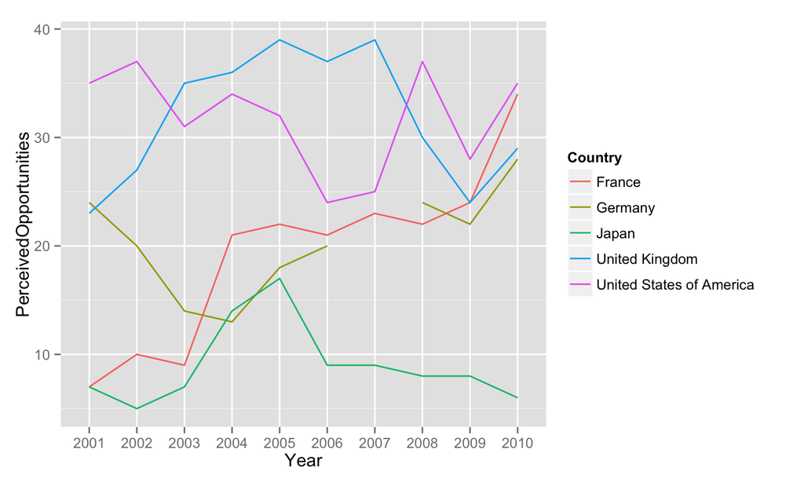

## Regression Results

- Our regression equations were run both with and without considering country-specific effects. For the purposes of illustrating our results, we have chosen to ignore the country-specific effects.
- We decided to do this because the coefficients do not change significantly when the country-specific effects are ignored.

## Results: PercentIntention as a Dependent Variable

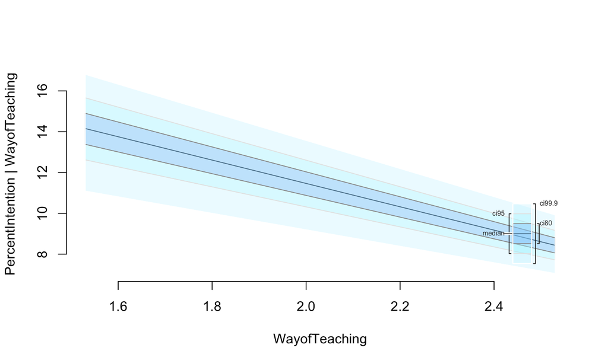

## Results: PercentIntention as a Dependent Variable

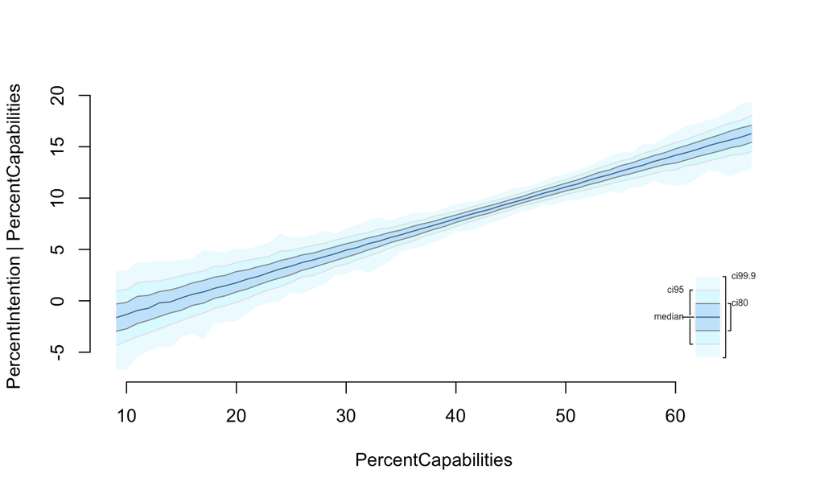

## Conclusions

- Some expected trends observed
- Inconclusive results
- Lack of reliable data